# Simulation Results (500 reps)

# Simulation setup: a 15 fold scenario

- S1: D = 0.05 ; sigma = 200 m ; L0 = 2
- S2: D = 0.0033 ; sigma = 3000 m ; L0 = 0.133
- reps = 500
- a rep was excluded if:
  - an estimate was NA or infinite
  - the RSE for one of the parameters is > 100
  - an estimate was more than 5 fold away from the true value

# Grids with 800 m spacing

### Data summary

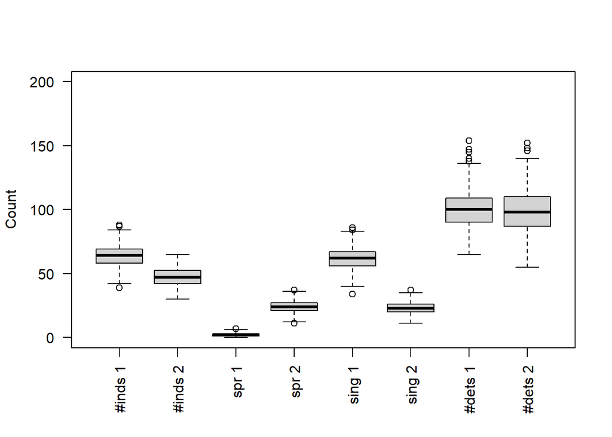

### Simulation Results

Sim Results from 800 m Grids

| Strata | D RB | D RSE | L0 RB | L0 RSE | Sigma RB | Sigma RSE | Reps |
| --- | --- | --- | --- | --- | --- | --- | --- |
| S1 | 10.1 | 0.315 | 1.3 | 0.208 | -1.9 | 0.125 | 487 |
| S2 | 12.8 | 0.470 | 0.0 | 0.194 | 4.9 | 0.358 | 414 |

# Grids with 1600 m spacing

### Data summary

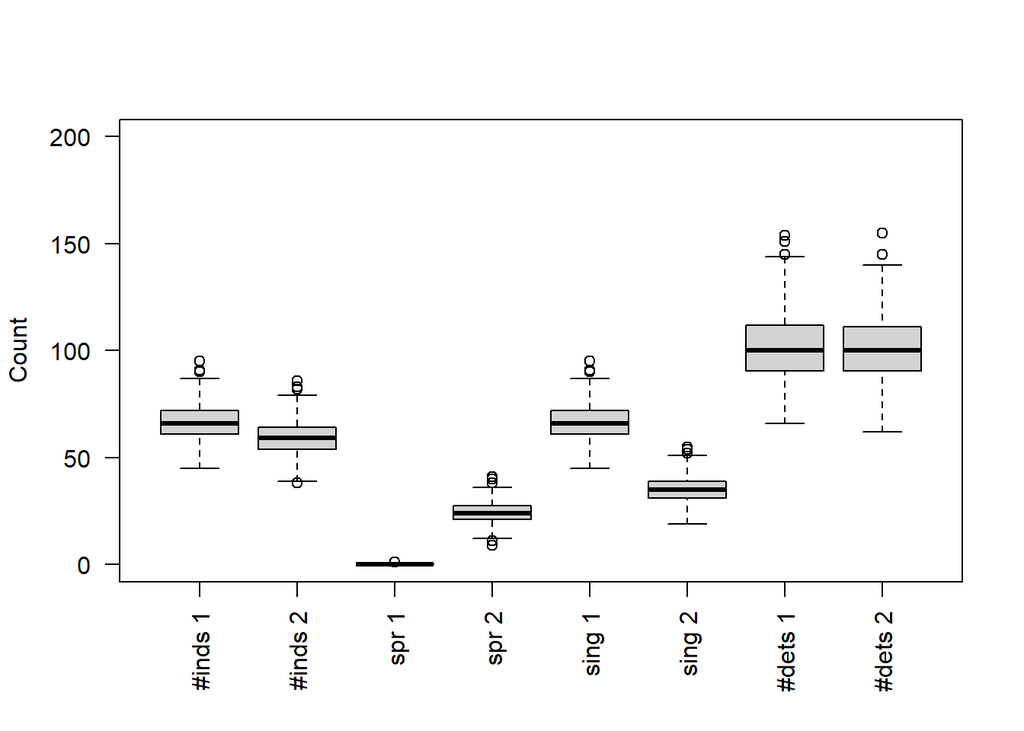

### Simulation Results

Sim Results from 1600 m Grids

| Strata | D RB | D RSE | L0 RB | L0 RSE | Sigma RB | Sigma RSE | Reps |
| --- | --- | --- | --- | --- | --- | --- | --- |
| S1 | 20.5 | 0.594 | 1.4 | 0.191 | 0.3 | 0.206 | 476 |
| S2 | 2.7 | 0.236 | 0.3 | 0.217 | 1.9 | 0.156 | 500 |

# GA4 Designs (min(n,r))

## Data summaries

**Using S1 values:**

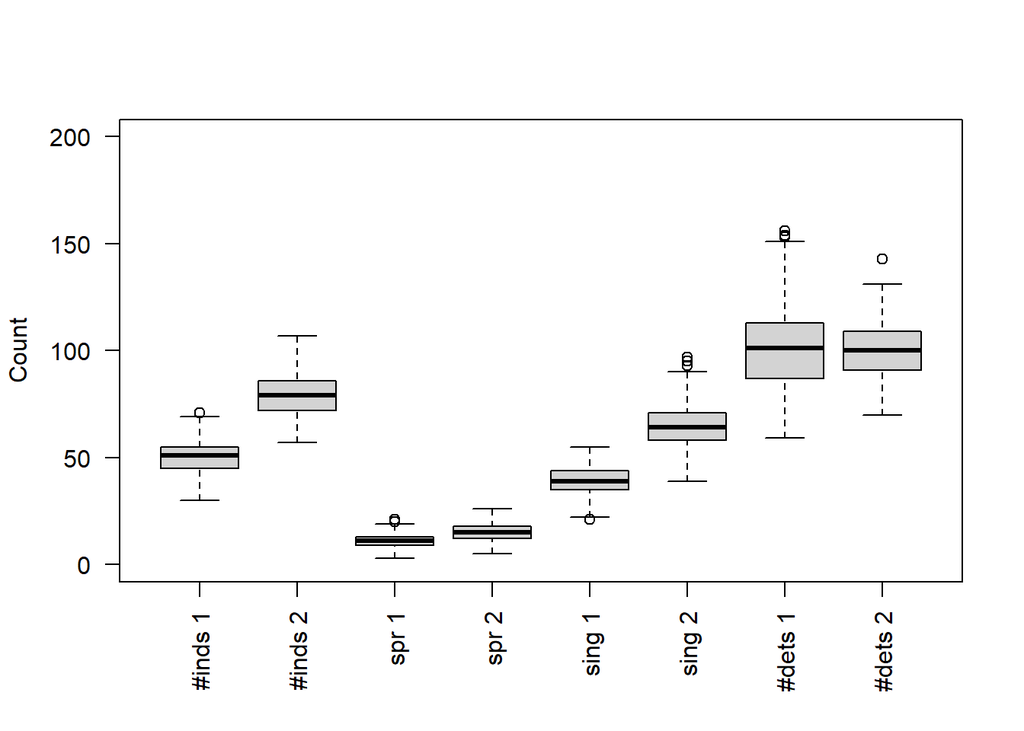

**Using S2 values:**

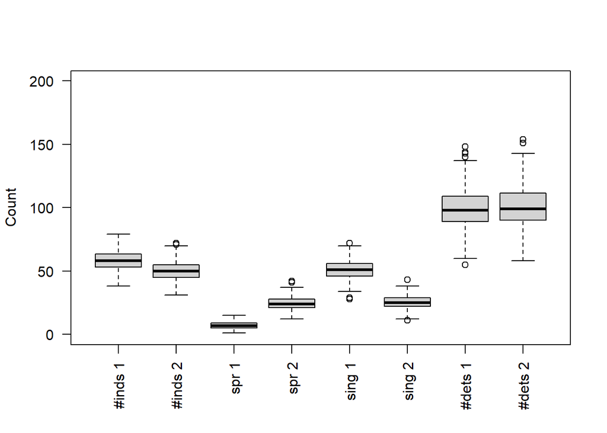

**Using Avg values:**

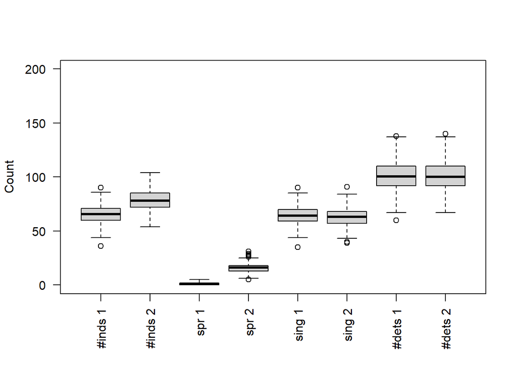

**Using Both values:**

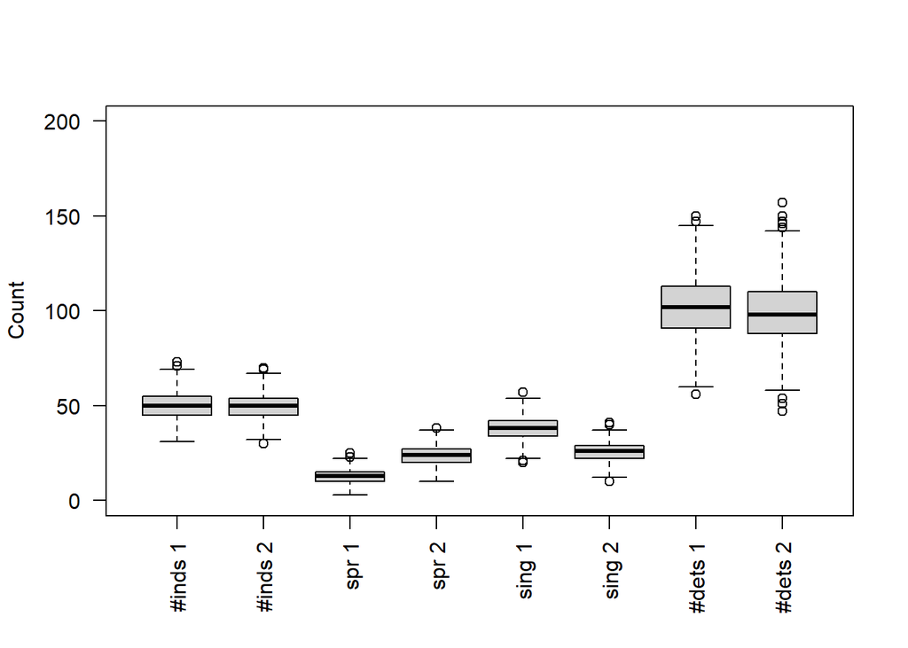

**Using Both (max-min) values:**

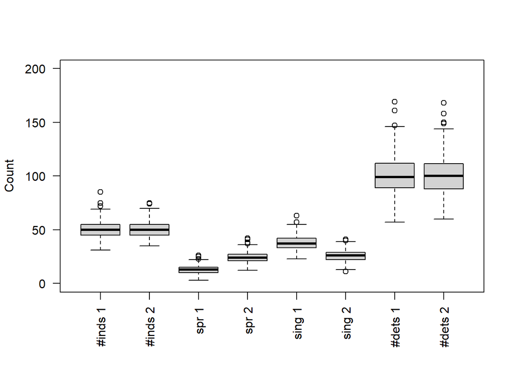

## Simulation Results

Sim Results from GA4 designs

| Values | Strata | D RB | D RSE | L0 RB | L0 RSE | Sigma RB | Sigma RSE | Reps |
| --- | --- | --- | --- | --- | --- | --- | --- | --- |
| S1 | S1 | 4.6 | 0.320 | 0.5 | 0.187 | 1.9 | 0.182 | 499 |
|  | S2 | 11.3 | 0.345 | 0.5 | 0.258 | -0.8 | 0.156 | 499 |
| S2 | S1 | 8.1 | 0.274 | -1.0 | 0.197 | -1.2 | 0.127 | 500 |
|  | S2 | 3.5 | 0.348 | 3.2 | 0.195 | 3.1 | 0.245 | 489 |
| Avg | S1 | 44.0 | 0.687 | -0.8 | 0.204 | -3.8 | 0.274 | 469 |
|  | S2 | 5.6 | 0.229 | 2.4 | 0.279 | 0.0 | 0.142 | 500 |
| Both | S1 | 4.3 | 0.218 | 1.9 | 0.186 | -0.7 | 0.108 | 500 |
|  | S2 | 4.1 | 0.380 | 1.2 | 0.205 | 3.5 | 0.238 | 496 |
| Both (Max) | S1 | 3.0 | 0.222 | -0.8 | 0.185 | 0.7 | 0.185 | 500 |
|  | S2 | 6.2 | 0.396 | 1.2 | 0.189 | 3.8 | 0.189 | 496 |

**Using S1 values:**

**Using S2 values:**

**Using Avg values:**

**Using Both values:**

**Using Both (max-min) values:**

# GA5 Designs (E(n2))

## Data summaries

**Using S1 values:**

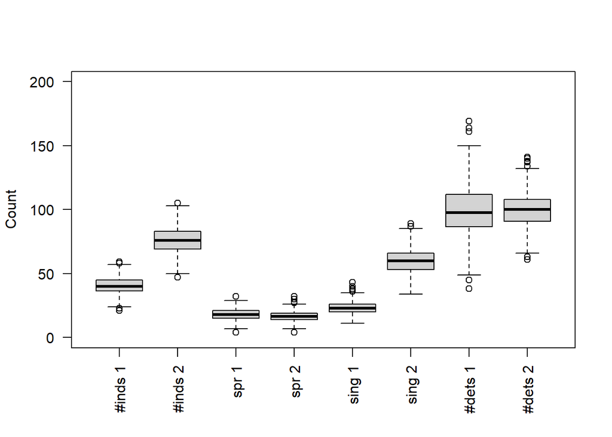

**Using S2 values:**

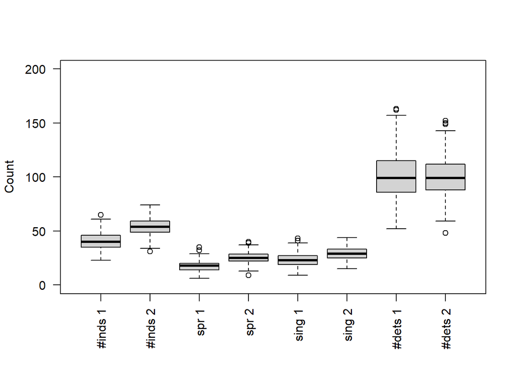

**Using Avg values:**

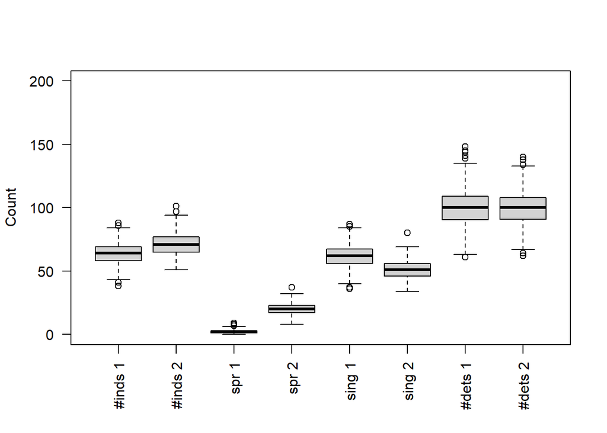

**Using Both values:**

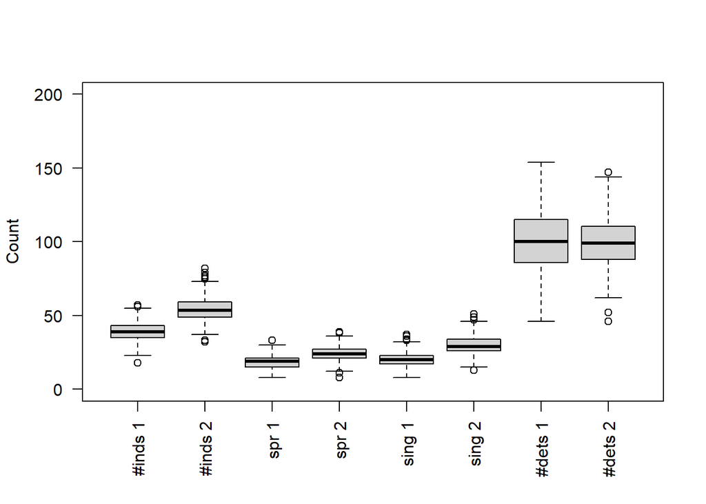

**Using Both (max-min) values:**

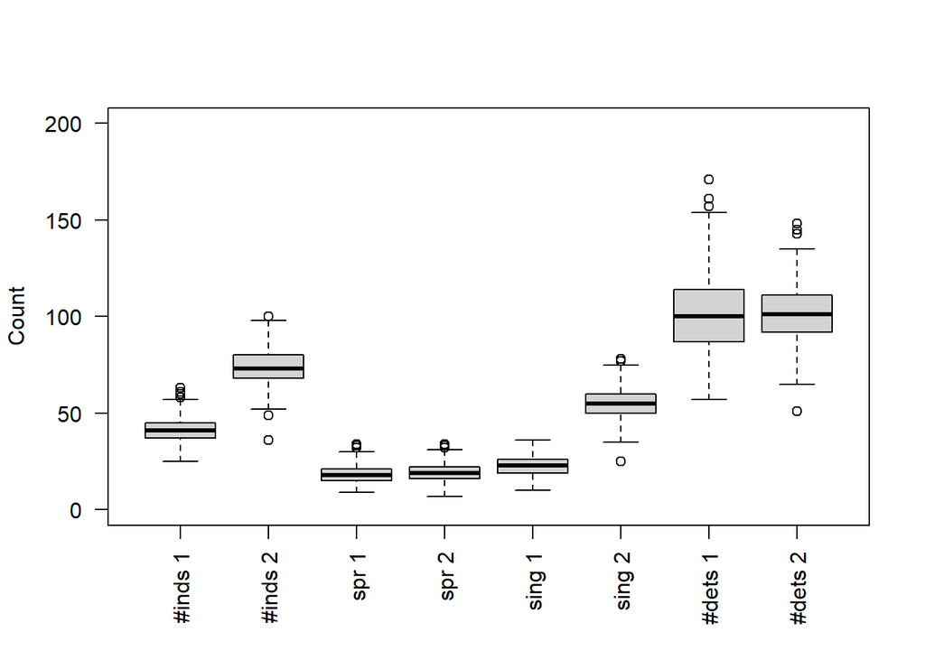

## Simulation Results

Sim Results from GA5 designs

| Values | Strata | D RB | D RSE | L0 RB | L0 RSE | Sigma RB | Sigma RSE | Reps |
| --- | --- | --- | --- | --- | --- | --- | --- | --- |
| S1 | S1 | 3.5 | 0.259 | -0.9 | 0.193 | 0.7 | 0.143 | 500 |
|  | S2 | 13.0 | 0.353 | 2.1 | 0.254 | -2.2 | 0.167 | 498 |
| S2 | S1 | 2.5 | 0.180 | -0.6 | 0.182 | 0.2 | 0.086 | 500 |
|  | S2 | 5.0 | 0.314 | 1.9 | 0.201 | 0.8 | 0.172 | 499 |
| Avg | S1 | 32.6 | 0.573 | -0.6 | 0.203 | -4.5 | 0.228 | 472 |
|  | S2 | 2.0 | 0.200 | 4.2 | 0.252 | -0.5 | 0.131 | 500 |
| Both | S1 | 1.7 | 0.227 | 0.2 | 0.185 | 0.3 | 0.108 | 500 |
|  | S2 | 1.7 | 0.302 | 0.9 | 0.197 | 2.4 | 0.189 | 498 |
| Both (Max) | S1 | 3.9 | 0.260 | 0.2 | 0.186 | 0.7 | 0.186 | 499 |
|  | S2 | 8.7 | 0.283 | 2.0 | 0.245 | -0.6 | 0.245 | 500 |

**Using S1 values:**

**Using S2 values:**

**Using Avg values:**

**Using Both values:**

**Using Both (max-min) values:**

# General comments:

## Grid design

- The grids do not work particularly well
  - spacing of 800 m produces positive bias in D for both strata with a high RSE for strata 2. There was also a high proportion of reps that were excluded for strata 2 (17.2%, and 2.6% for strata 1).
  - spacing of 1600 m produces high positive bias in D for strata 1 along with a high RSE and an exlcusion rate of 4.8%
  - I do not understand how sigma is estimated so well, even with zero spatial recaptures the estimator for sigma appears unbiased?

## GA4 (min(n,r))

- The behaviour of the GA4 algorithm seems to spread traps much further when using S1 or avg values. I think this is due to the fairly high L0 values that make it easier to get high r so the algorithm spreads traps to increase n. The other settings produce a fairly dense array with traps tending to be quite close together.
- Using average values does not work well and results in high positive bias in D for strata 1 with a high RSE and an exclusion rate of 6.2%.
- The other configurations appear unbiased except for slight positive positive bias in D for strata 2 when using strata 1 values (and slightly lower bias for strata 1 when using strata 2 values).
- The best option appears to be using both sets of values with minimal differences between a 50-50 weighting and the max-min approach
- I’m not sure why when using S2 values there were a handful of reps (2.2%) that gave problems for S2. The data summary shows more spatial recaps and less singletons for S2 (with slightly lower n).

## GA5 (min En2)

- The behaviour of the GA5 algorithm consistently produces clusters of traps, except when using average values. Using S2 values produces two large clusters, and using both with max-min tends to produce clusters that are more spread out compared to without max-min, and appear similar to when using S1 values.
- Using avg values leads to high bias and variance with an exclusion rate of 5.6% in strata 1.
- Using S1 values leads to positive bias in D for S2 but not the other way round
- Using both sets of values works well. There is not a lot of difference from the max-min approach though that does seem to exhibit a low degree of positive bias in D especially for strata 2.
- GA5 seems marginally better than GA4 with slightly lower and better balance across the strata in RSE’s in D